# Lab 5: Wide and Deep Network Architures

```python
def wide_deep_3layer(X_train, X_test, y_train, y_test, cross_columns):

    brier = []

    for i in [0,1,2,3,4,6,7,8,9]:
        brier_temp = wide_and_deep_3layer_1fold(X_train, X_test, y_train, y_test, cross_columns, i)
        brier.append(brier_temp)

    return brier
```

```
[[561 347]
 [320 578]] 0.6307469854694231
```

```
[[628 280]
 [332 566]] 0.6609597441205617
```

```
[[611 297]
 [318 579]] 0.65919621940978
```

```
[[592 316]
 [305 592]] 0.6559800411552948
```

```
[[567 341]
 [268 629]] 0.6628378245645052
```

```
[[631 276]
 [351 546]] 0.6521978812137482
```

```
[[604 303]
 [324 573]] 0.652363814700232
```

```
[[654 253]
 [341 556]] 0.6704511792954341
```

```
[[603 304]
 [310 587]] 0.6596163371965107
```

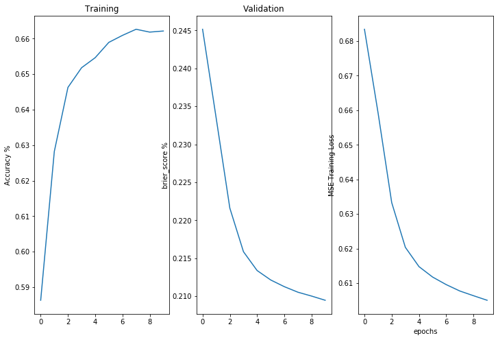

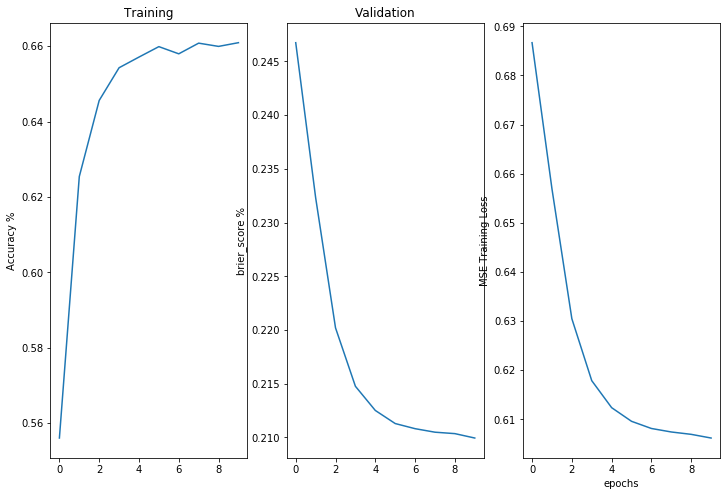

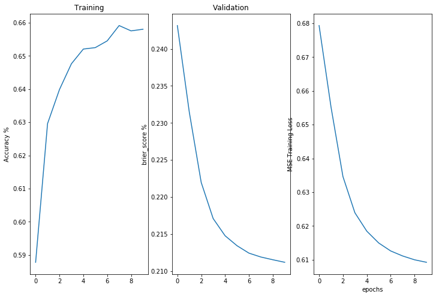

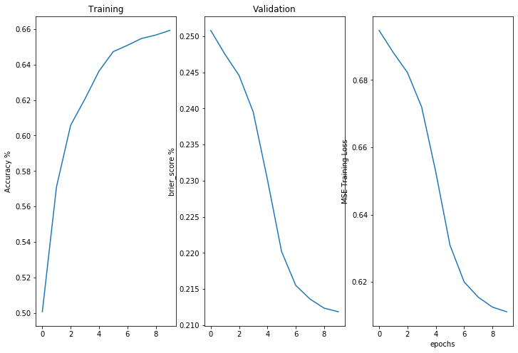

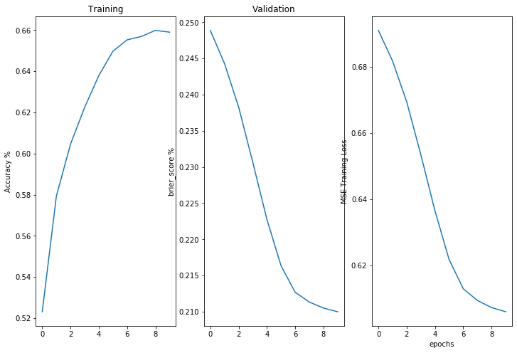

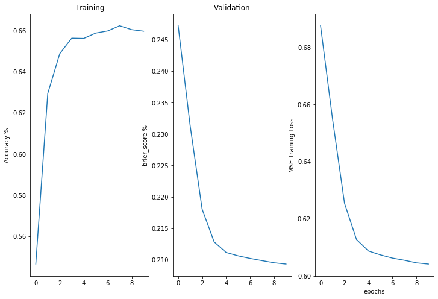

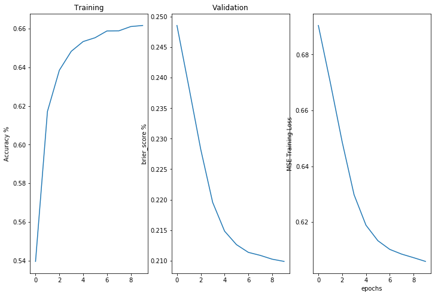

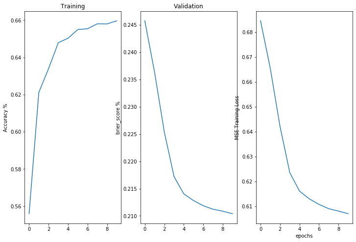

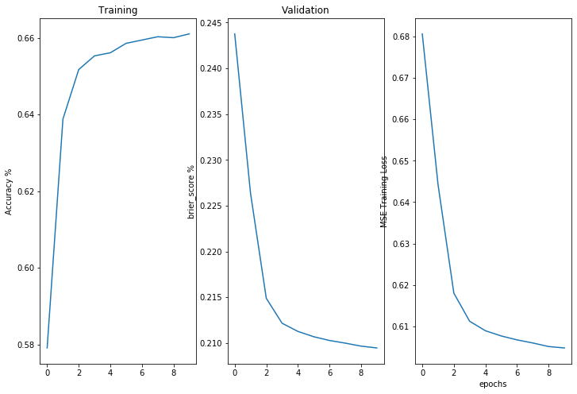

```python
brier1 = wide_deep_3layer(X_train, X_test, y_train, y_test, cross_columns1)
```

```
[[561 347]
 [289 609]] 0.648007564534011
```

```
[[632 276]
 [322 576]] 0.6687303160228801
```

```
[[605 303]
 [298 599]] 0.667040526669908
```

```
[[649 259]
 [358 539]] 0.657824785506264
```

```
[[631 277]
 [325 572]] 0.6663075400625679
```

```
[[498 409]
 [244 653]] 0.6385225036536095
```

```
[[626 281]
 [347 550]] 0.6516711960362792
```

```
[[644 263]
 [336 561]] 0.6677255681378207
```

```
[[646 261]
 [364 533]] 0.653220523145263
```

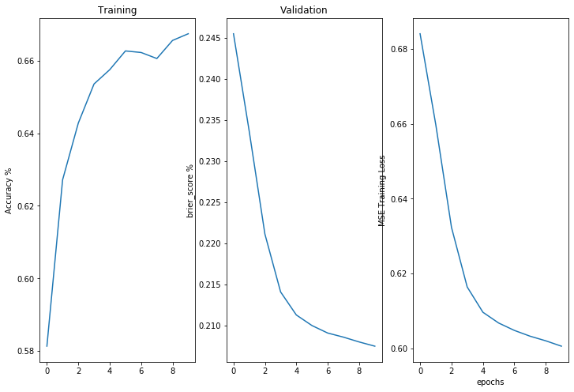

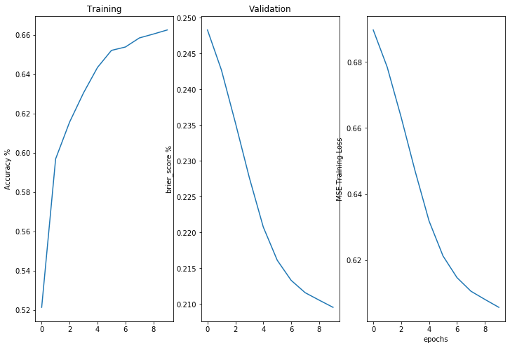

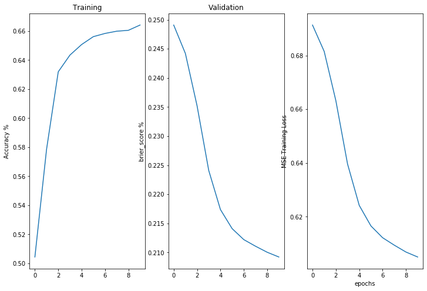

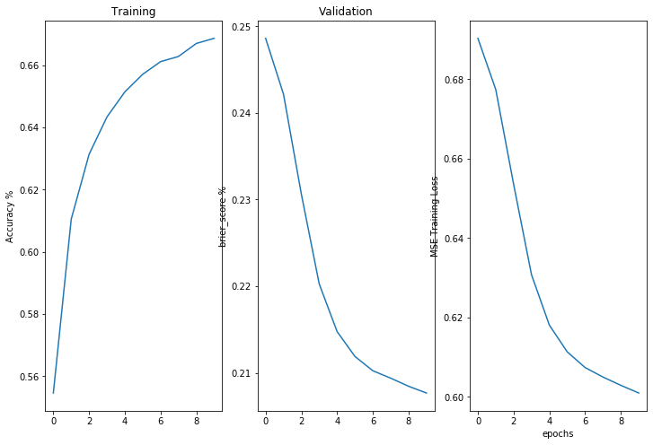

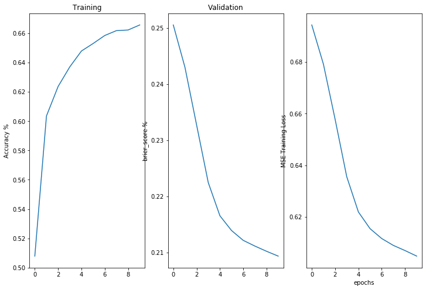

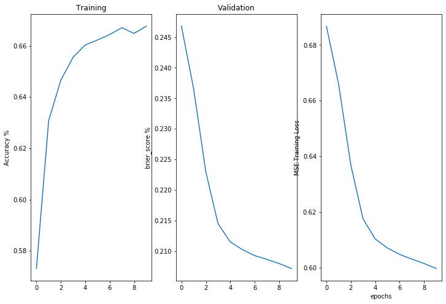

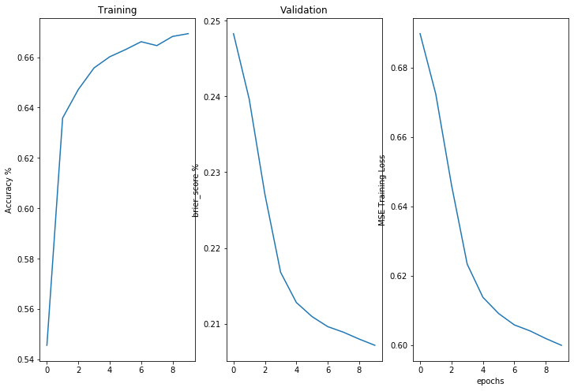

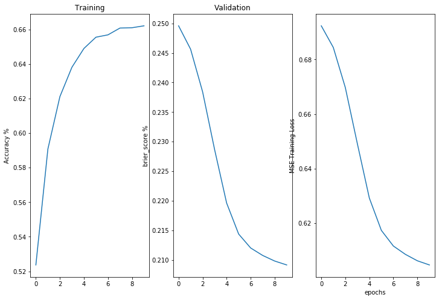

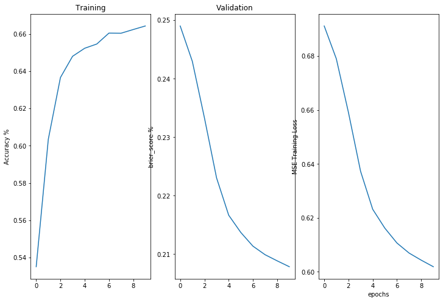

```python
brier2 = wide_deep_3layer(X_train, X_test, y_train, y_test, cross_columns2)
```

```
[[565 343]
 [326 572]] 0.6296088714029219
```

```
[[634 274]
 [335 563]] 0.6625933302591172
```

```
[[593 315]
 [285 612]] 0.6676789739660838
```

```
[[655 253]
 [364 533]] 0.6577842686586222
```

```
[[576 332]
 [280 617]] 0.6611048084903669
```

```
[[623 284]
 [357 540]] 0.6444432562787388
```

```
[[647 260]
 [362 535]] 0.6548866182632541
```

```
[[611 296]
 [290 607]] 0.6751747525440062
```

```
[[617 290]
 [337 560]] 0.6522839207993323
```

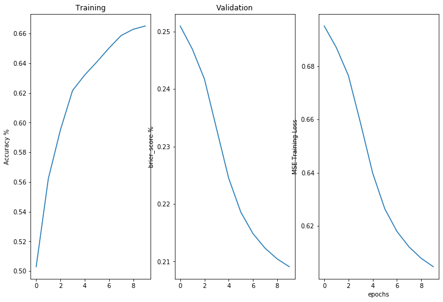

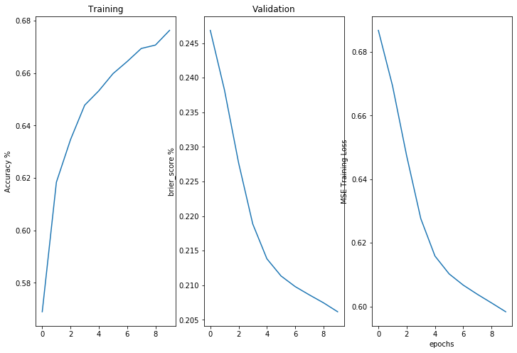

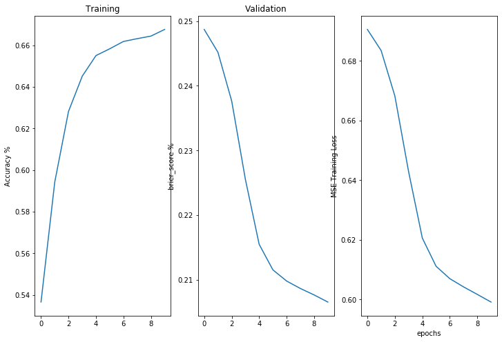

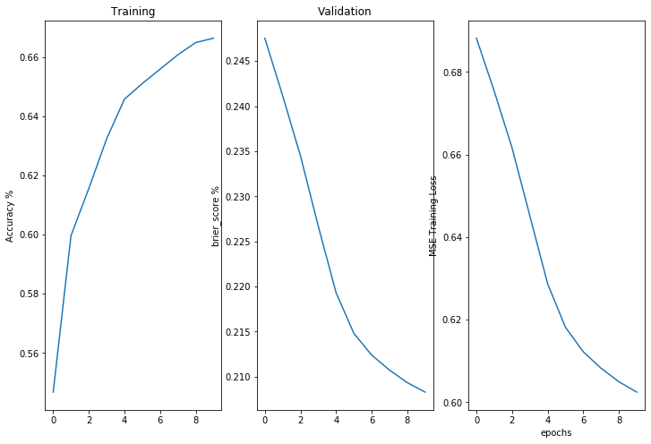

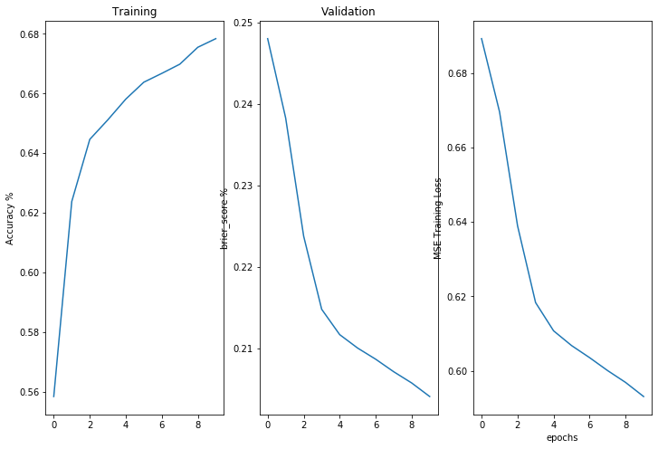

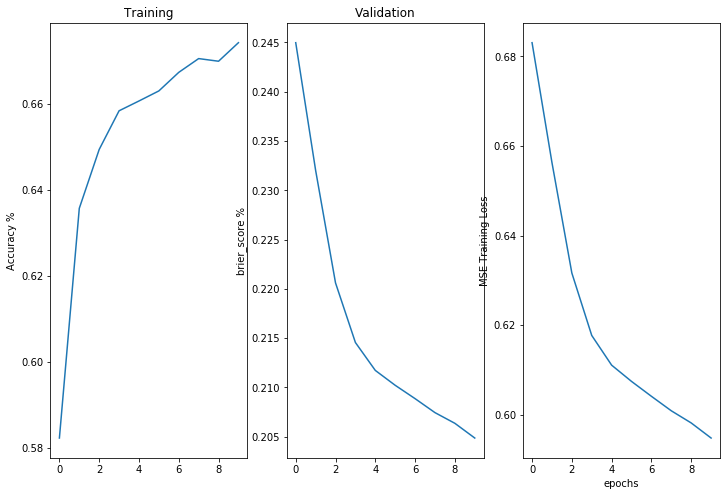

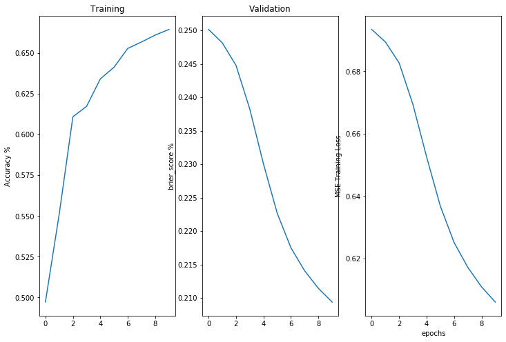

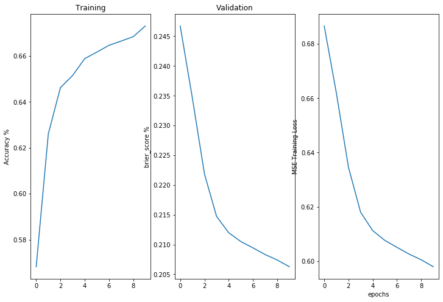

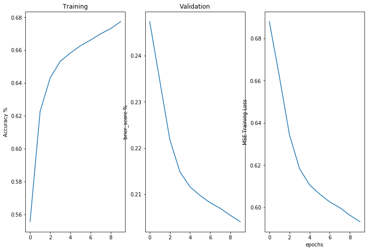

```python
brier3 = wide_deep_3layer(X_train, X_test, y_train, y_test, cross_columns3)
```

# Wide and Deep 5 Layers

```python
# 'workclass','education','marital_status',
# 'occupation','relationship','race',
# 'sex','country'
#cross_columns3 = [['opening_category', 'opening_eco'],
#                 ['increment_code', 'rated_str'],
#                 ['first','second', 'third', 'fourth', 'fifth', 'sixth', 'seventh', 'eighth', 'ninth', 'tenth']]

history=[]

def wide_and_deep_5layer_1fold(X_train, X_test, y_train, y_test, cross_columns, i):


    X_train_num =  X_train[i][numeric_headers].values
    X_test_num = X_test[i][numeric_headers].values
    #'workclass','education','marital_status','occupation','relationship','race','sex','country'

    # we need to create separate lists for each branch
    embed_branches = []
    X_ints_train = []
    X_ints_test = []
    all_inputs = []
    all_wide_branch_outputs = []

    for cols in cross_columns:
        # encode crossed columns as ints for the embedding
        enc = LabelEncoder()

        # create crossed labels
        X_crossed_train = X_train[i][cols].apply(lambda x: '_'.join(x), axis=1)
        X_crossed_test = X_test[i][cols].apply(lambda x: '_'.join(x), axis=1)

        enc.fit(np.hstack((X_crossed_train.values,  X_crossed_test.values)))
        X_crossed_train = enc.transform(X_crossed_train)
        X_crossed_test = enc.transform(X_crossed_test)
        X_ints_train.append( X_crossed_train )
        X_ints_test.append( X_crossed_test )

        # get the number of categories
        N = max(np.hstack((X_ints_train[-1],X_ints_test[-1])))+1 # same as the max(df_train[col])

        # create embedding branch from the number of categories
        inputs = Input(shape=(1,),dtype='int32', name = '_'.join(cols))
        all_inputs.append(inputs)
        x = Embedding(input_dim=N,
                      output_dim=int(np.sqrt(N)),
                      input_length=1, name = '_'.join(cols)+'_embed')(inputs)
        x = Flatten()(x)
        all_wide_branch_outputs.append(x)

    # merge the branches together
    wide_branch = concatenate(all_wide_branch_outputs, name='wide_concat')
    wide_branch = Dense(units=1,activation='sigmoid',name='wide_combined')(wide_branch)

    # reset this input branch
    all_deep_branch_outputs = []
    # add in the embeddings
    for col in categorical_headers:
        # encode as ints for the embedding
        enc = LabelEncoder()

        # 1. create crossed labels by join operation
        X_crossed_train = X_train[i][cols].apply(lambda x: '_'.join(x), axis=1)
        X_crossed_test = X_test[i][cols].apply(lambda x: '_'.join(x), axis=1)

        # 2. encode as integers
        enc.fit(np.hstack((X_crossed_train.values,  X_crossed_test.values)))
        X_crossed_train = enc.transform(X_crossed_train)
        X_crossed_test = enc.transform(X_crossed_test)

        # 3. save encodings in a list for each branch
        X_ints_train.append( X_crossed_train )
        X_ints_test.append( X_crossed_test )

        # get the number of categories
        N = max(np.hstack((X_ints_train[-1],X_ints_test[-1])))+1 # same as the max(df_train[col])

        # create embedding branch from the number of categories
        inputs = Input(shape=(1,),dtype='int32', name=col)
        all_inputs.append(inputs)
        x = Embedding(input_dim=N,
                      output_dim=int(np.sqrt(N)),
                      input_length=1, name=col+'_embed')(inputs)
        x = Flatten()(x)
        all_deep_branch_outputs.append(x)

    # also get a dense branch of the numeric features
    all_inputs.append(Input(shape=(X_train_num.shape[1],),
                            sparse=False,
                            name='numeric_data'))

    x = Dense(units=20, activation='relu',name='numeric_1')(all_inputs[-1])
    all_deep_branch_outputs.append( x )

    # merge the deep branches together
    deep_branch = concatenate(all_deep_branch_outputs,name='concat_embeds')
    deep_branch = Dense(units=50,activation='relu', name='deep1')(deep_branch)
    deep_branch = Dense(units=25,activation='relu', name='deep2')(deep_branch)
    deep_branch = Dense(units=10,activation='relu', name='deep3')(deep_branch)

    final_branch = concatenate([wide_branch, deep_branch],name='concat_deep_wide')
    final_branch = Dense(units=1,activation='sigmoid',name='combined')(final_branch)

    model = Model(inputs=all_inputs, outputs=final_branch)


    model.compile(optimizer='sgd',
                  loss='binary_crossentropy',
                  metrics=['accuracy', brier_score])

    history = model.fit(X_ints_train + [X_train_num], # create a list of inputs for embeddings
            y_train[i], epochs=10, batch_size=32, verbose=1)

    yhat = np.round(model.predict(X_ints_test + [X_test_num]))
    print(mt.confusion_matrix(y_test[i],yhat),mt.roc_auc_score(y_test[i],yhat))
    #print(i)

    #Also add the visulization part use the "history" return parameter

    plt.figure(figsize=(12,8))
    plt.subplot(1,3,1)
    plt.plot(history.history['accuracy'])
    plt.ylabel('Accuracy %')
    plt.title('Training')

    plt.subplot(1,3,2)
    plt.plot(history.history['brier_score'])
    plt.ylabel('brier_score %')
    plt.title('Validation')

    plt.subplot(1,3,3)
    plt.plot(history.history['loss'])
    plt.ylabel('MSE Training Loss')
    plt.xlabel('epochs')

    return brier_score_calc(yhat, y_test[i])
```

```python
def wide_deep_5layer(X_train, X_test, y_train, y_test, cross_columns):

    brier = []

    for i in [0,1,2,3,4,6,7,8,9]:
        brier_temp = wide_and_deep_5layer_1fold(X_train, X_test, y_train, y_test, cross_columns, i)
        brier.append(brier_temp)

    return brier
```

```
[[620 288]
 [381 517]] 0.6292716069974393
```

```
[[611 297]
 [323 575]] 0.6566096464978464
```

```
[[561 347]
 [285 612]] 0.6500578285916345
```

```
[[620 288]
 [313 584]] 0.6669392345508033
```

```
[[528 380]
 [247 650]] 0.6530677392581243
```

```
[[550 357]
 [280 617]] 0.6471215456642808
```

```
[[623 284]
 [348 549]] 0.6494599786867655
```

```
[[581 326]
 [264 633]] 0.6731294686809762
```

```
[[636 271]
 [349 548]] 0.6560690479965682
```

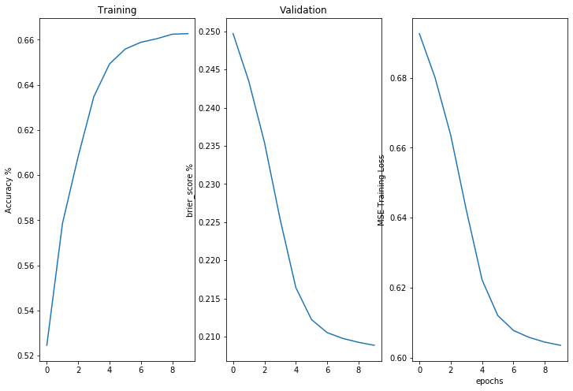

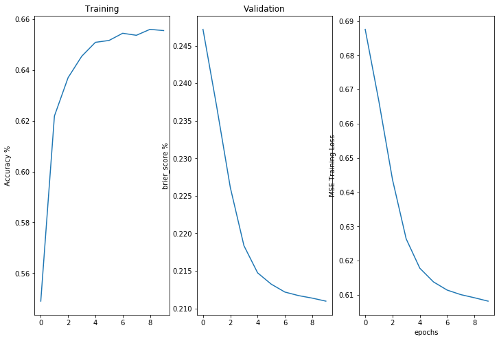

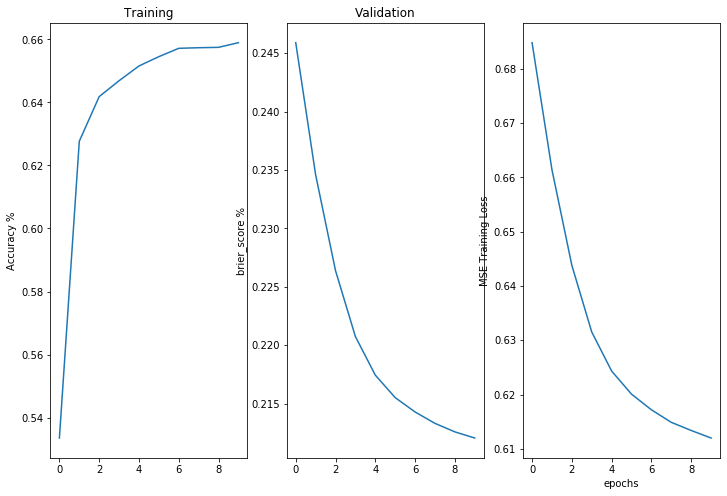

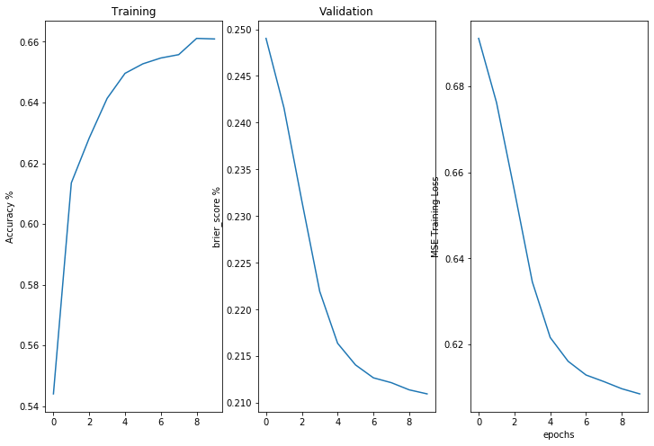

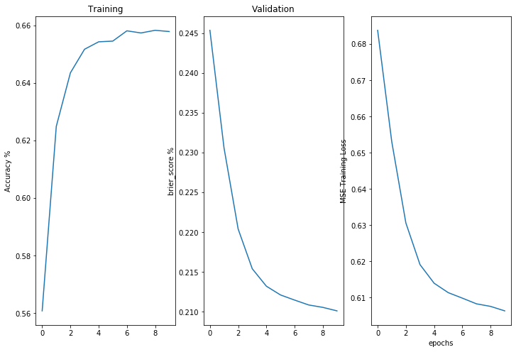

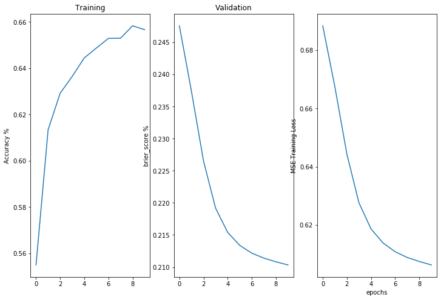

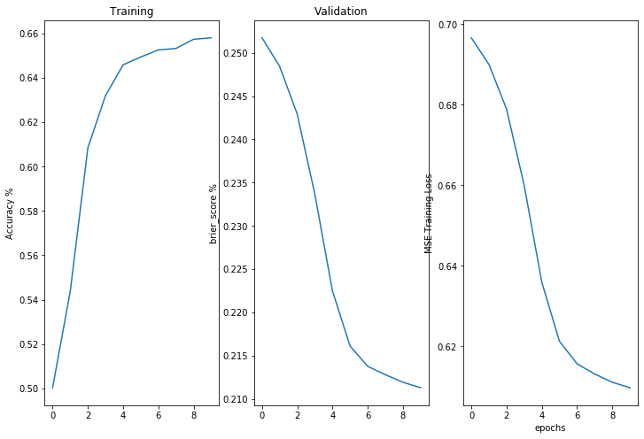

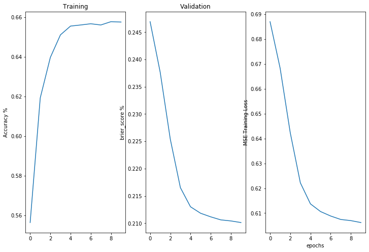

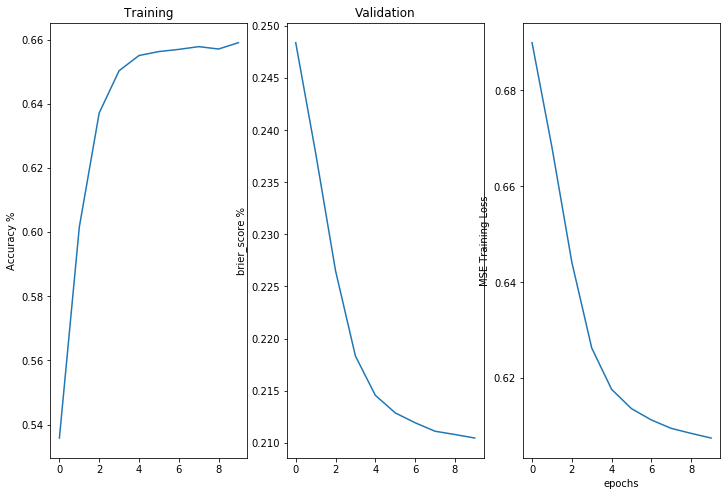

```python
brier4 = wide_deep_5layer(X_train, X_test, y_train, y_test, cross_columns1)
```

```python
brier5 = wide_deep_5layer(X_train, X_test, y_train, y_test, cross_columns2)
```

[output not shown]

```python
brier6 = wide_deep_5layer(X_train, X_test, y_train, y_test, cross_columns3)
```

[output not shown]

Since we just fixed the 10-fold training problem (with your help), we run different models with different PCs. And the results are provided as below.

```python
brier5=[0.359911,0.340532,0.335734,0.342382,0.336288,0.360865,0.34867,0.33592,0.349778]
```

```python
brier6=[0.34735,0.344457,0.358687,0.358375,0.358539,0.337134,0.348946,0.359168,0.34588]
```

```python
SVG(model_to_dot(brier1).create(prog='dot', format='svg'))
```

```python
SVG(model_to_dot(brier2).create(prog='dot', format='svg'))
```

```python
SVG(model_to_dot(brier3).create(prog='dot', format='svg'))
```

```python
SVG(model_to_dot(brier4).create(prog='dot', format='svg'))
```

# Model Compare

```python
# from keras.models import Sequential
from keras.layers import Dense, Activation, Input
from keras.layers import Embedding, Flatten, Concatenate
from keras.models import Model
from sklearn.metrics import roc_auc_score

from sklearn import metrics as mt
```

## Compare Model with Different Layers

```python
# brier1 = [0,1,50,4]
# brier2 = [-50,-50,-50,-50]
# brier3 = [4,4,4,4]
# brier4 = [100,100,100,100]
# brier5 = [-50,-50,-50,-50]
# brier6 = [0,0,0,0]



briers = [brier2, brier3, brier4, brier5, brier6]
from scipy import stats

best = [brier1]
best_idx = [0]
for idx1, brier_comp1 in enumerate(briers):
    ttest_results = stats.ttest_ind(brier_comp1, best[0])
    if (ttest_results[1] < 0.05):
        if (np.mean(brier_comp1) < np.mean(best[0])):
            best = [brier_comp1]
            best_idx = [idx1+2]
    else:
        best.append(brier_comp1)
        best_idx.append(idx1+2)

for i, val in enumerate(best_idx):
    if val == 0:
        best_idx[i] = 1

print(best)
print(best_idx)
```

[output not shown]

We compare 3-layer model with 5-layer model of the same cross feature product.

```python
ttest_results14 = stats.ttest_ind(brier1, brier4)
ave1 = np.mean(brier1)
ave2 = np.mean(brier4)

if ttest_results[1] < 0.05:
    if (ave1 < ave2):
        print('3 layer is better')
    else:
        print('5 layer is better')
else:
    print('Both perform the same')
```

```
Both perform the same
```

```python
ttest_results25 = stats.ttest_ind(brier2, brier5)
ave1 = np.mean(brier2)
ave2 = np.mean(brier5)

if ttest_results[1] < 0.05:
    if (ave1 < ave2):
        print('3 layer is better')
    else:
        print('5 layer is better')
else:
    print('Both perform the same')
```

```
Both perform the same
```

```python
ttest_results36 = stats.ttest_ind(brier3, brier6)
ave1 = np.mean(brier3)
ave2 = np.mean(brier6)

if ttest_results[1] < 0.05:
    if (ave1 < ave2):
        print('3 layer is better')
    else:
        print('5 layer is better')
else:
    print('Both perform the same')
```

```
Both perform the same
```

Since the models' performs are very similiar, we will process with the simplest model, which is the first model. The best model including 'opening_category', 'opening_eco','increment_code', 'rated_str','first','second'.

## Standard MLP

```python
# combine the features into a single large matrix

for idx in [0,1,2,3,4,5,6,7,8,9]:
    feature_columns = ['white_rating', 'black_rating', 'stockfish']
    X_train_mlp = X_train[idx][feature_columns].values
    X_test_mlp = X_test[idx][feature_columns].values

    # This returns a tensor
    inputs = Input(shape=(X_train_mlp.shape[1],))

    # a layer instance is callable on a tensor, and returns a tensor
    x = Dense(units=20, activation='relu', name = 'numeric_1')(inputs)
    #x = Dense(units=10, activation='relu', name = 'numeric_2')(x)
    predictions = Dense(1,activation='sigmoid')(x)

    # This creates a model that includes
    # the Input layer and three Dense layers
    model = Model(inputs=inputs, outputs=predictions)

    model.compile(optimizer='sgd',
                  loss='mean_squared_error',
                  metrics=['accuracy'])

    #model.summary()

    model.fit(X_train_mlp, y_train[idx], epochs=10, batch_size=32, verbose=1)


    yhat_proba = model.predict(X_test_mlp)
    yhat = np.round(yhat_proba)
    print('Fold:', idx)
    print(mt.confusion_matrix(y_test[idx],yhat),mt.roc_auc_score(y_test[idx],yhat))
```

```
Fold: 0
[[600 308]
 [348 550]] 0.6366325559490988
Fold: 1
[[621 287]
 [327 571]] 0.6598890829351569
Fold: 2
[[606 302]
 [304 593]] 0.6642467058575083
Fold: 3
[[606 302]
 [314 583]] 0.6586725698485898
Fold: 4
[[583 325]
 [293 604]] 0.6577130572294333
Fold: 5
[[581 326]
 [302 595]] 0.6519477518470854
Fold: 6
[[646 261]
 [381 516]] 0.6437444919301014
Fold: 7
[[599 308]
 [336 561]] 0.6429185119084933
Fold: 8
[[620 287]
 [312 585]] 0.6678730645702509
Fold: 9
[[629 278]
 [347 550]] 0.653324999784901
```

```python
model.summary()
```

```
Model: "model_74"
_________________________________________________________________
Layer (type)                 Output Shape              Param #
=================================================================
input_10 (InputLayer)        (None, 3)                 0
_________________________________________________________________
numeric_1 (Dense)            (None, 20)                80
_________________________________________________________________
dense_10 (Dense)             (None, 1)                 21
=================================================================
Total params: 101
Trainable params: 101
Non-trainable params: 0
_________________________________________________________________
```

## Our Best Model

```python
cross_columns1 = [['opening_category', 'opening_eco'],
                 ['increment_code', 'rated_str'],
                 ['first','second']]
```

```python
brier_score_lst = []

# we need to create separate sequential models for each embedding
embed_branches = []
X_ints_train = [] # keep track of inputs for each branch
X_ints_test = []# keep track of inputs for each branch
all_inputs = [] # this is what we will give to keras.Model inputs
all_branch_outputs = [] # this is where we will keep track of output of each branch


for cols in cross_columns1:
    # encode as ints for the embedding
    enc = LabelEncoder()

    # 1. create crossed labels by join operation
    X_crossed_train = X_train[0][cols].apply(lambda x: '_'.join(x), axis=1)
    X_crossed_test = X_test[0][cols].apply(lambda x: '_'.join(x), axis=1)

    # 2. encode as integers
    enc.fit(np.hstack((X_crossed_train.values,  X_crossed_test.values)))
    X_crossed_train = enc.transform(X_crossed_train)
    X_crossed_test = enc.transform(X_crossed_test)

    # 3. save encodings in a list for each branch
    X_ints_train.append( X_crossed_train )
    X_ints_test.append( X_crossed_test )

    # get the number of categories in the crossing
    N = max(X_ints_train[-1]+1) # same as the max(df_train[col]
    #print(N)

    # create embedding branch from the number of categories
    inputs = Input(shape=(1,),dtype= 'int32', name='_'.join(cols))
    all_inputs.append( inputs ) # keep track of created inputs
    x = Embedding(input_dim=N,
                  output_dim=int(np.sqrt(N)),
                  input_length=1, name='_'.join(cols)+'_embed')(inputs)
    x = Flatten()(x)
    all_branch_outputs.append(x)



X_train_num = X_train[0][numeric_headers]


all_inputs.append(Input(shape=(X_train_num.shape[1],),sparse=False, name='numeric'))
x = Dense(units=20, activation='relu',name='numeric_1')(all_inputs[-1])
all_branch_outputs.append( Dense(units=10,activation='relu', name='numeric_2')(x) )

# merge the branches together
final_branch = concatenate(all_branch_outputs, name='concat_1')
final_branch = Dense(units=1,activation='sigmoid', name='combined')(final_branch)

model = Model(inputs=all_inputs, outputs=final_branch)

model.compile(optimizer='sgd',
      loss='mean_squared_error',
      metrics= [brier_score, 'accuracy'])






model.fit(X_ints_train + [X_train_num], # create a list of inputs for embeddings
y_train[0], epochs=10, batch_size=32, verbose=1) #change epochs later

X_test_num = X_test[0][numeric_headers].values
print(len(X_ints_test))
print(X_test_num)
yhat = np.round(model.predict(X_ints_test + [X_test_num]))
print(mt.confusion_matrix(y_test[0],yhat),mt.roc_auc_score(y_test[0],yhat))
brier_score_lst.append(brier_score_calc(yhat, y_test[0]))
```

```
3
[[-1.52068729 -0.32220627 -1.40267539 ... -0.23127184 -0.05971883
   1.2731593 ]
 [-1.42823283 -0.95666248 -1.15277665 ...  0.40758619 -0.14327271
  -0.07188385]
 [-0.04141598 -0.33646371 -0.29955096 ...  0.40758619 -0.14327271
   0.46295614]
 ...
 [-0.84268794  0.56175519 -0.16746163 ... -0.23127184 -0.26860353
   0.35175178]
 [-1.58232359 -0.8461673  -0.05679219 ...  0.00829992  0.065612
  -0.5431785 ]
 [-1.58232359 -0.78913753  0.09671703 ...  0.00829992 -0.14327271
   2.07277157]]
[[575 333]
 [326 572]] 0.6351154793324373
```

The standard MLP is slightly better than our model based on ROC and AUC.

# Exceptional Work - t-SNE(10 Points)

## t-SNE Explanation

T-SNE, also known as t-distributed stochastic neighbor embedding (t-SNE), is a non-linear unsupervised technique to achieve dimensionality reduction. T-SNE attempts to preserve the structure of the high dimensional space in lower dimensions by preserving local distances. The classic example is that of the spiral or other curved manifold. T-SNE will “follow the spiral.” T-SNE uses a probability distribution over pairs of points Pij where if i and j are close together Pij is larger and if i and j are far apart then Pij is small.

There are three steps to the t-SNE Algorithm. The first step is to calculate the similarity points in the original (high) dimension and the target (low) dimensional spaces.

The following equation is used to calculate the probabilities in high dimensional map. $$P_{j|i} = \frac{exp(-\left \| x_{i}-x_{j} \right \|^{2} /2\sigma ^{2})}{\Sigma _{k}\Sigma _{i\not\equiv j} exp(-\left \| x_{i}-x_{j} \right \|^{2} /2\sigma ^{2})}$$ Equation taken from Laurens van der Maaten's Google Tech talk https://www.youtube.com/watch?v=RJVL80Gg3lA

The numerator is simply the Gaussian. The denominator is made specifically for the i,j points as a way of 'scaling.' Thus, if in some parts of the high-dimensional manifold are more dense than others parts, the points that are most similar in high dimensional space will appear thesame distance apart in the visualization. The last step is to average $P_{i|j}$ and $P_{j|i}$ and divide by 2N.

The following equation is used to calculate the conditional probabilities in the low dimensional map. $$q_{i,j} = \frac{(1+\left \| y_{i}-y_{j} \right \|^{2})^{-1}}{\Sigma _{k}\Sigma _{t\not\equiv k} (1+\left \| y_{k}-y_{l} \right \|^{2})^{-1} }$$

Note that in the above equation we use the Student-t distribution but not a Gaussian. This is because points that are far away might have to become further away in the lower dimensional space to preserve local distances. Since the Student-T distribution has a heavier tail, the distribution allows for points to be further away in the lower dimensional visualization.

Last, we must measure how well the distances are conserved in the low-dimensional space vs. the high dimensional space. In other words, we need to minimize the divergence. To do this, we will use the Kullback-Leibler Divergence:

$$ KL(P||Q) = \sum_{i} \sum_{j\neq i} p_{ij} log\frac{p_{ij}}{q_{ij}} $$

This is used because if there is large $p_{ij}$ (points are close together in high dimensional space) then they should have a high $q_{ij}$. But on the other hand, if there is a small $p_{ij}$ (high dimensional space objects are far apart), then the algorithm doesn't care if they are put together in low dimensional space. Thus, the algorithm tries to maintain local distances. Finally, we use gradient descent to find the(a) minimum value.

We captured the embedding weights (called embeddings), then reduced their number of dimension to two using t-SNE dimension reduction from SKLearn. Now all the outputs of these embedding layers have two dimension and could be drawn in a two dimensional graph. These embedding weights are visualiszed in the following.

## Citations for t-SNE

Chang, R. (2019). What advantages does the t-SNE algorithm have over PCA?. [online] Quora.com. Available at: https://www.quora.com/What-advantages-does-the-t-SNE-algorithm-have-over-PCA [Accessed 14 Sep. 2019].

En.wikipedia.org. (2019). Kullback–Leibler divergence. [online] Available at: https://en.wikipedia.org/wiki/Kullback–Leibler_divergence [Accessed 14 Sep. 2019].

Pathak, M. (2019). Introduction to t-SNE. [online] DataCamp Community. Available at: https://www.datacamp.com/community/tutorials/introduction-t-sne [Accessed 14 Sep. 2019].

van der Maaten, L. (2019). t-SNE. [online] Laurens van der Maaten. Available at: https://lvdmaaten.github.io/tsne/ [Accessed 14 Sep. 2019].

van der Maaten, L. (2019). Visualizing Data Using t-SNE. [online] YouTube. Available at: https://www.youtube.com/watch?v=RJVL80Gg3lA [Accessed 14 Sep. 2019].

van der Maaten, L. and Hinton, G. (2019). Visualizing Data using t-SNE. [online] Jmlr.org. Available at: http://www.jmlr.org/papers/volume9/vandermaaten08a/vandermaaten08a.pdf [Accessed 14 Sep. 2019].

```python
cross_columns_tsne = ['opening_category', 'opening_eco',
 'increment_code', 'rated_str',
 'first', 'second']
```

```python
import numpy as np
from sklearn.manifold import TSNE

count = 0

for layer in model.layers:
    if (count > 0):
        break
    count += 1
    for idx,name in enumerate(cross_columns_tsne):
        print('cross columns')
        if layer.get_config()['name'] == name:
            h = layer.get_weights()

        tsne = TSNE(n_components = 3, verbose = 1, perplexity = 30, n_iter = 3000)
        Y_embed_tsne = tsne.fit_transform(h[0])

        fig = plt.figure(figsize=(6, 4))
        plt.subplot(2,3,idx+1)
        ax = fig.add_subplot(111)
        plt.scatter(Y_embed_tsne[:, 0], Y_embed_tsne[:, 2], c=Y_embed_tsne.argmax(1),  cmap=plt.cm.get_cmap('RdYlGn'),
        marker='+', alpha=0.5, lw=1)
        plt.title("t-SNE clustering for: " + str(name))
        ax.xaxis.set_major_formatter(NullFormatter())
        ax.yaxis.set_major_formatter(NullFormatter())

        print('plot show')
        plt.show()
```

```python
import numpy as np
from sklearn.manifold import TSNE
Y_embed_tsne=[]

for idx,name in enumerate(cross_columns_tsne):
    if layer.get_config()['name'] == name:
        h = layer.get_weights()

    tsne = TSNE(n_components = 3, verbose = 1, perplexity = 30, n_iter = 3000)
    Y_embed_tsne.append(tsne.fit_transform(h[0]))
```

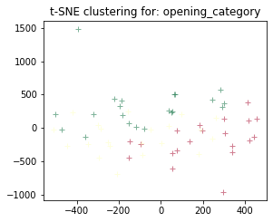

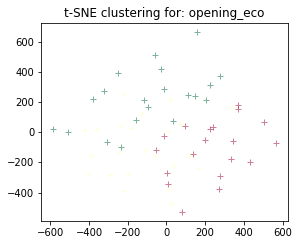

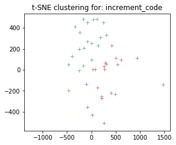

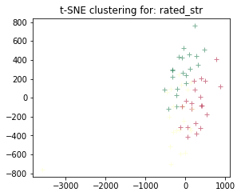

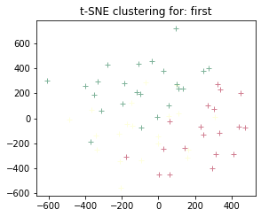

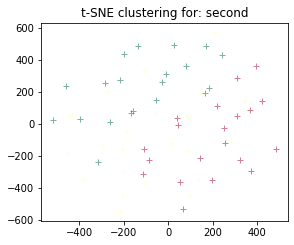

```python
for i in range(6):
    fig = plt.figure(figsize=(15, 8))
    plt.subplot(2,3,i+1)
    plt.scatter(Y_embed_tsne[i][:, 0], Y_embed_tsne[i][:, 2], c=Y_embed_tsne[i].argmax(1),  cmap=plt.cm.get_cmap('RdYlGn'),
            marker='+', alpha=0.5, lw=1)
    plt.title("t-SNE clustering for: " + str(cross_columns_tsne[i]))
    plt.show()
```

```python
Y_embed_tsne=np.vstack(Y_embed_tsne)
```

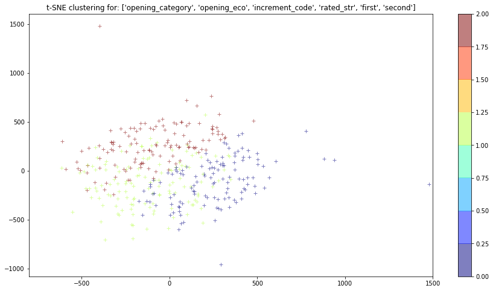

```python
fig = plt.figure(figsize=(15, 8))

plt.scatter(Y_embed_tsne[:, 0], Y_embed_tsne[:, 2], c=Y_embed_tsne.argmax(1),  cmap=plt.cm.get_cmap('jet',8),
        marker='+', alpha=0.5, lw=1)
plt.xlim(-800, 1500)
plt.colorbar()
plt.title("t-SNE clustering for: " + str(cross_columns_tsne))
plt.show()
```

We have scattered all the weights in different curves. These curves do not show a good clustering. It is a good way to see behavior of weights and compare.